# Risk Factor Analysis

## Outcome Variable

**Outcome Variable:** ever_wasted

## Predictor Variables

**Intervention Variable:** mbmi

**Adjustment Set:**

- arm
- W_mage
- meducyrs
- feducyrs
- hhwealth_quart
- W_nchldlt5
- brthmon
- W_parity
- delta_W_mage
- delta_meducyrs
- delta_feducyrs
- delta_hhwealth_quart
- delta_W_nchldlt5
- delta_brthmon
- delta_W_parity

## Stratifying Variables

The analysis was stratified on these variable(s):

- agecat
- studyid
- country

## Data Summary

| agecat | studyid | country | mbmi | ever_wasted | n_cell | n |
| --- | --- | --- | --- | --- | --- | --- |
| 0-24 months | ki0047075b-MAL-ED | BANGLADESH | Normal weight | 0 | 154 | 254 |
| 0-24 months | ki0047075b-MAL-ED | BANGLADESH | Normal weight | 1 | 68 | 254 |
| 0-24 months | ki0047075b-MAL-ED | BANGLADESH | Underweight | 0 | 15 | 254 |
| 0-24 months | ki0047075b-MAL-ED | BANGLADESH | Underweight | 1 | 17 | 254 |
| 0-24 months | ki0047075b-MAL-ED | BRAZIL | Normal weight | 0 | 194 | 221 |
| 0-24 months | ki0047075b-MAL-ED | BRAZIL | Normal weight | 1 | 17 | 221 |
| 0-24 months | ki0047075b-MAL-ED | BRAZIL | Underweight | 0 | 8 | 221 |
| 0-24 months | ki0047075b-MAL-ED | BRAZIL | Underweight | 1 | 2 | 221 |
| 0-24 months | ki0047075b-MAL-ED | INDIA | Normal weight | 0 | 105 | 242 |
| 0-24 months | ki0047075b-MAL-ED | INDIA | Normal weight | 1 | 88 | 242 |
| 0-24 months | ki0047075b-MAL-ED | INDIA | Underweight | 0 | 20 | 242 |
| 0-24 months | ki0047075b-MAL-ED | INDIA | Underweight | 1 | 29 | 242 |
| 0-24 months | ki0047075b-MAL-ED | NEPAL | Normal weight | 0 | 164 | 238 |
| 0-24 months | ki0047075b-MAL-ED | NEPAL | Normal weight | 1 | 74 | 238 |
| 0-24 months | ki0047075b-MAL-ED | NEPAL | Underweight | 0 | 0 | 238 |
| 0-24 months | ki0047075b-MAL-ED | NEPAL | Underweight | 1 | 0 | 238 |
| 0-24 months | ki0047075b-MAL-ED | PERU | Normal weight | 0 | 260 | 290 |
| 0-24 months | ki0047075b-MAL-ED | PERU | Normal weight | 1 | 25 | 290 |
| 0-24 months | ki0047075b-MAL-ED | PERU | Underweight | 0 | 3 | 290 |
| 0-24 months | ki0047075b-MAL-ED | PERU | Underweight | 1 | 2 | 290 |
| 0-24 months | ki0047075b-MAL-ED | SOUTH AFRICA | Normal weight | 0 | 205 | 270 |
| 0-24 months | ki0047075b-MAL-ED | SOUTH AFRICA | Normal weight | 1 | 57 | 270 |
| 0-24 months | ki0047075b-MAL-ED | SOUTH AFRICA | Underweight | 0 | 8 | 270 |
| 0-24 months | ki0047075b-MAL-ED | SOUTH AFRICA | Underweight | 1 | 0 | 270 |
| 0-24 months | ki0047075b-MAL-ED | TANZANIA, UNITED REPUBLIC OF | Normal weight | 0 | 210 | 256 |
| 0-24 months | ki0047075b-MAL-ED | TANZANIA, UNITED REPUBLIC OF | Normal weight | 1 | 32 | 256 |
| 0-24 months | ki0047075b-MAL-ED | TANZANIA, UNITED REPUBLIC OF | Underweight | 0 | 10 | 256 |
| 0-24 months | ki0047075b-MAL-ED | TANZANIA, UNITED REPUBLIC OF | Underweight | 1 | 4 | 256 |
| 0-24 months | ki1000304b-SAS-CompFeed | INDIA | Normal weight | 0 | 646 | 1390 |
| 0-24 months | ki1000304b-SAS-CompFeed | INDIA | Normal weight | 1 | 373 | 1390 |

[output cut: 170 more lines]

The following strata were considered:

- agecat: 0-24 months, studyid: ki0047075b-MAL-ED, country: BANGLADESH
- agecat: 0-24 months, studyid: ki0047075b-MAL-ED, country: BRAZIL
- agecat: 0-24 months, studyid: ki0047075b-MAL-ED, country: INDIA
- agecat: 0-24 months, studyid: ki0047075b-MAL-ED, country: NEPAL
- agecat: 0-24 months, studyid: ki0047075b-MAL-ED, country: PERU
- agecat: 0-24 months, studyid: ki0047075b-MAL-ED, country: SOUTH AFRICA
- agecat: 0-24 months, studyid: ki0047075b-MAL-ED, country: TANZANIA, UNITED REPUBLIC OF
- agecat: 0-24 months, studyid: ki1000304b-SAS-CompFeed, country: INDIA
- agecat: 0-24 months, studyid: ki1017093-NIH-Birth, country: BANGLADESH
- agecat: 0-24 months, studyid: ki1017093b-PROVIDE, country: BANGLADESH
- agecat: 0-24 months, studyid: ki1017093c-NIH-Crypto, country: BANGLADESH
- agecat: 0-24 months, studyid: ki1066203-TanzaniaChild2, country: TANZANIA, UNITED REPUBLIC OF
- agecat: 0-24 months, studyid: ki1112895-iLiNS-Zinc, country: BURKINA FASO
- agecat: 0-24 months, studyid: ki1119695-PROBIT, country: BELARUS
- agecat: 0-24 months, studyid: ki1126311-ZVITAMBO, country: ZIMBABWE
- agecat: 0-24 months, studyid: ki1148112-LCNI-5, country: MALAWI
- agecat: 0-24 months, studyid: kiGH5241-JiVitA-3, country: BANGLADESH
- agecat: 0-6 months, studyid: ki0047075b-MAL-ED, country: BANGLADESH
- agecat: 0-6 months, studyid: ki0047075b-MAL-ED, country: BRAZIL
- agecat: 0-6 months, studyid: ki0047075b-MAL-ED, country: INDIA
- agecat: 0-6 months, studyid: ki0047075b-MAL-ED, country: NEPAL
- agecat: 0-6 months, studyid: ki0047075b-MAL-ED, country: PERU
- agecat: 0-6 months, studyid: ki0047075b-MAL-ED, country: SOUTH AFRICA
- agecat: 0-6 months, studyid: ki0047075b-MAL-ED, country: TANZANIA, UNITED REPUBLIC OF
- agecat: 0-6 months, studyid: ki1000304b-SAS-CompFeed, country: INDIA
- agecat: 0-6 months, studyid: ki1017093-NIH-Birth, country: BANGLADESH
- agecat: 0-6 months, studyid: ki1017093b-PROVIDE, country: BANGLADESH
- agecat: 0-6 months, studyid: ki1017093c-NIH-Crypto, country: BANGLADESH
- agecat: 0-6 months, studyid: ki1066203-TanzaniaChild2, country: TANZANIA, UNITED REPUBLIC OF
- agecat: 0-6 months, studyid: ki1119695-PROBIT, country: BELARUS
- agecat: 0-6 months, studyid: ki1126311-ZVITAMBO, country: ZIMBABWE
- agecat: 0-6 months, studyid: ki1148112-LCNI-5, country: MALAWI
- agecat: 0-6 months, studyid: kiGH5241-JiVitA-3, country: BANGLADESH
- agecat: 6-24 months, studyid: ki0047075b-MAL-ED, country: BANGLADESH
- agecat: 6-24 months, studyid: ki0047075b-MAL-ED, country: BRAZIL
- agecat: 6-24 months, studyid: ki0047075b-MAL-ED, country: INDIA
- agecat: 6-24 months, studyid: ki0047075b-MAL-ED, country: NEPAL
- agecat: 6-24 months, studyid: ki0047075b-MAL-ED, country: PERU
- agecat: 6-24 months, studyid: ki0047075b-MAL-ED, country: SOUTH AFRICA
- agecat: 6-24 months, studyid: ki0047075b-MAL-ED, country: TANZANIA, UNITED REPUBLIC OF
- agecat: 6-24 months, studyid: ki1000304b-SAS-CompFeed, country: INDIA
- agecat: 6-24 months, studyid: ki1017093-NIH-Birth, country: BANGLADESH
- agecat: 6-24 months, studyid: ki1017093b-PROVIDE, country: BANGLADESH
- agecat: 6-24 months, studyid: ki1017093c-NIH-Crypto, country: BANGLADESH
- agecat: 6-24 months, studyid: ki1066203-TanzaniaChild2, country: TANZANIA, UNITED REPUBLIC OF
- agecat: 6-24 months, studyid: ki1112895-iLiNS-Zinc, country: BURKINA FASO
- agecat: 6-24 months, studyid: ki1119695-PROBIT, country: BELARUS
- agecat: 6-24 months, studyid: ki1126311-ZVITAMBO, country: ZIMBABWE
- agecat: 6-24 months, studyid: ki1148112-LCNI-5, country: MALAWI
- agecat: 6-24 months, studyid: kiGH5241-JiVitA-3, country: BANGLADESH

### Dropped Strata

Some strata were dropped due to rare outcomes:

- agecat: 0-24 months, studyid: ki0047075b-MAL-ED, country: BRAZIL
- agecat: 0-24 months, studyid: ki0047075b-MAL-ED, country: NEPAL
- agecat: 0-24 months, studyid: ki0047075b-MAL-ED, country: PERU
- agecat: 0-24 months, studyid: ki0047075b-MAL-ED, country: SOUTH AFRICA
- agecat: 0-24 months, studyid: ki0047075b-MAL-ED, country: TANZANIA, UNITED REPUBLIC OF
- agecat: 0-6 months, studyid: ki0047075b-MAL-ED, country: BRAZIL
- agecat: 0-6 months, studyid: ki0047075b-MAL-ED, country: NEPAL
- agecat: 0-6 months, studyid: ki0047075b-MAL-ED, country: PERU
- agecat: 0-6 months, studyid: ki0047075b-MAL-ED, country: SOUTH AFRICA
- agecat: 0-6 months, studyid: ki0047075b-MAL-ED, country: TANZANIA, UNITED REPUBLIC OF
- agecat: 0-6 months, studyid: ki1148112-LCNI-5, country: MALAWI
- agecat: 6-24 months, studyid: ki0047075b-MAL-ED, country: BRAZIL
- agecat: 6-24 months, studyid: ki0047075b-MAL-ED, country: NEPAL
- agecat: 6-24 months, studyid: ki0047075b-MAL-ED, country: PERU
- agecat: 6-24 months, studyid: ki0047075b-MAL-ED, country: SOUTH AFRICA
- agecat: 6-24 months, studyid: ki0047075b-MAL-ED, country: TANZANIA, UNITED REPUBLIC OF

## Methods Detail

We’re interested in the causal parameters $E[Y_a]$ for all values of $a \in \mathcal{A}$. These parameters represent the mean outcome if, possibly contrary to fact, we intervened to set all units to have $A=a$. Under the randomization and positivity assumptions, these are identified by the statistical parameters $\psi_a=E_W[E_{Y|A,W}(Y|A=a,W)]$. In addition, we’re interested in the mean of $Y$, $E[Y]$ under no intervention (the observed mean). We will estimate these parameters by using SuperLearner to fit the relevant likelihood factors – $E_{Y|A,W}(Y|A=a,W)$ and $p(A=a|W)$, and then updating our likelihood fit using a joint TMLE.

For unadjusted analyses ($W=\{\}$), initial likelihoods were estimated using Lrnr_glm to estimate the simple $E(Y|A)$ and Lrnr_mean to estimate $p(A)$. For adjusted analyses, a small library containing Lrnr_glmnet, Lrnr_xgboost, and Lrnr_mean was used.

Having estimated these parameters, we will then use the delta method to estimate relative risks and attributable risks relative to a prespecified baseline level of $A$.

# Results Detail

## Results Plots

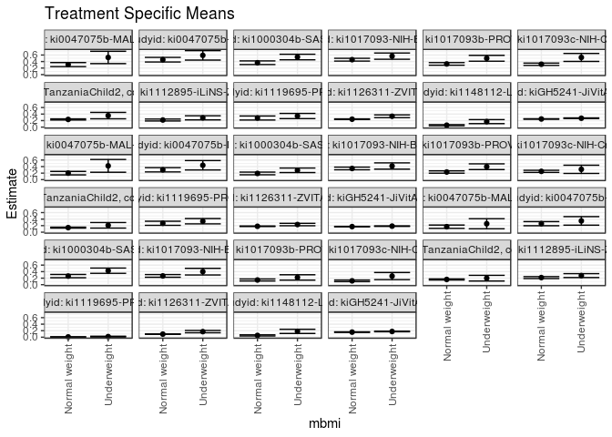

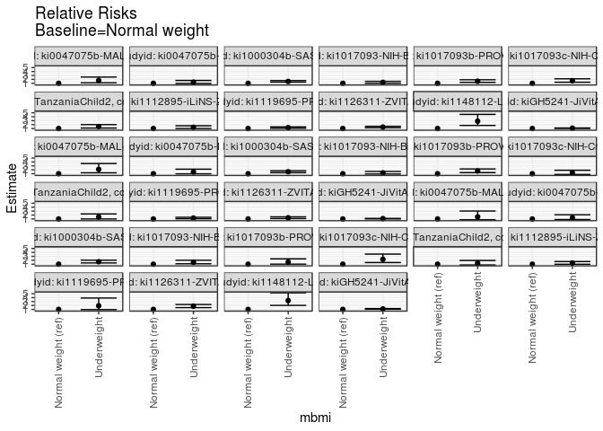

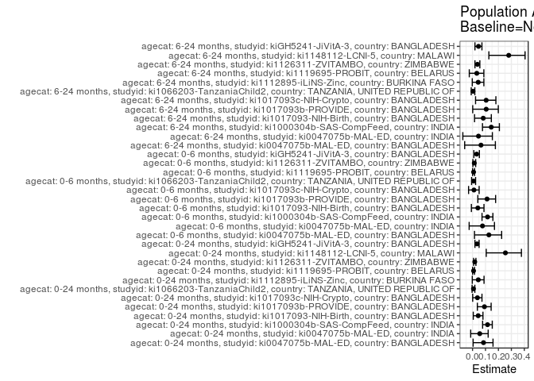

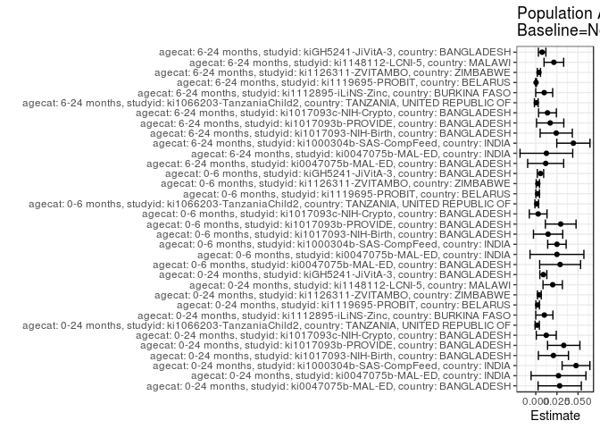

## Results Table

### Parameter: TSM

| agecat | studyid | country | intervention_level | baseline_level | estimate | ci_lower | ci_upper |
| --- | --- | --- | --- | --- | --- | --- | --- |
| 0-24 months | ki0047075b-MAL-ED | BANGLADESH | Normal weight | NA | 0.3063481 | 0.2445857 | 0.3681106 |
| 0-24 months | ki0047075b-MAL-ED | BANGLADESH | Underweight | NA | 0.5255018 | 0.3366094 | 0.7143943 |
| 0-24 months | ki0047075b-MAL-ED | INDIA | Normal weight | NA | 0.4565597 | 0.3859982 | 0.5271212 |
| 0-24 months | ki0047075b-MAL-ED | INDIA | Underweight | NA | 0.5895336 | 0.4446885 | 0.7343787 |
| 0-24 months | ki1000304b-SAS-CompFeed | INDIA | Normal weight | NA | 0.3631570 | 0.3074751 | 0.4188389 |
| 0-24 months | ki1000304b-SAS-CompFeed | INDIA | Underweight | NA | 0.5387566 | 0.4532303 | 0.6242828 |
| 0-24 months | ki1017093-NIH-Birth | BANGLADESH | Normal weight | NA | 0.4566760 | 0.4138052 | 0.4995468 |
| 0-24 months | ki1017093-NIH-Birth | BANGLADESH | Underweight | NA | 0.5651654 | 0.4692642 | 0.6610666 |
| 0-24 months | ki1017093b-PROVIDE | BANGLADESH | Normal weight | NA | 0.3271326 | 0.2873286 | 0.3669366 |
| 0-24 months | ki1017093b-PROVIDE | BANGLADESH | Underweight | NA | 0.4994433 | 0.4094986 | 0.5893880 |
| 0-24 months | ki1017093c-NIH-Crypto | BANGLADESH | Normal weight | NA | 0.3173852 | 0.2823657 | 0.3524048 |
| 0-24 months | ki1017093c-NIH-Crypto | BANGLADESH | Underweight | NA | 0.5258341 | 0.4032767 | 0.6483916 |
| 0-24 months | ki1066203-TanzaniaChild2 | TANZANIA, UNITED REPUBLIC OF | Normal weight | NA | 0.2354192 | 0.2179301 | 0.2529083 |
| 0-24 months | ki1066203-TanzaniaChild2 | TANZANIA, UNITED REPUBLIC OF | Underweight | NA | 0.3527702 | 0.2548638 | 0.4506767 |
| 0-24 months | ki1112895-iLiNS-Zinc | BURKINA FASO | Normal weight | NA | 0.2177320 | 0.1880652 | 0.2473988 |
| 0-24 months | ki1112895-iLiNS-Zinc | BURKINA FASO | Underweight | NA | 0.2846344 | 0.2221988 | 0.3470700 |
| 0-24 months | ki1119695-PROBIT | BELARUS | Normal weight | NA | 0.2794708 | 0.2177777 | 0.3411640 |
| 0-24 months | ki1119695-PROBIT | BELARUS | Underweight | NA | 0.3405362 | 0.2605320 | 0.4205403 |
| 0-24 months | ki1126311-ZVITAMBO | ZIMBABWE | Normal weight | NA | 0.2428922 | 0.2341610 | 0.2516234 |
| 0-24 months | ki1126311-ZVITAMBO | ZIMBABWE | Underweight | NA | 0.3325687 | 0.2898333 | 0.3753041 |
| 0-24 months | ki1148112-LCNI-5 | MALAWI | Normal weight | NA | 0.0588249 | 0.0412178 | 0.0764321 |
| 0-24 months | ki1148112-LCNI-5 | MALAWI | Underweight | NA | 0.1685723 | 0.1067523 | 0.2303922 |
| 0-24 months | kiGH5241-JiVitA-3 | BANGLADESH | Normal weight | NA | 0.2490955 | 0.2414545 | 0.2567365 |
| 0-24 months | kiGH5241-JiVitA-3 | BANGLADESH | Underweight | NA | 0.2725251 | 0.2631167 | 0.2819336 |
| 0-6 months | ki0047075b-MAL-ED | BANGLADESH | Normal weight | NA | 0.1995137 | 0.1466230 | 0.2524044 |
| 0-6 months | ki0047075b-MAL-ED | BANGLADESH | Underweight | NA | 0.4226305 | 0.2267081 | 0.6185530 |
| 0-6 months | ki0047075b-MAL-ED | INDIA | Normal weight | NA | 0.3013765 | 0.2363963 | 0.3663567 |
| 0-6 months | ki0047075b-MAL-ED | INDIA | Underweight | NA | 0.4402174 | 0.2957998 | 0.5846351 |
| 0-6 months | ki1000304b-SAS-CompFeed | INDIA | Normal weight | NA | 0.1904258 | 0.1492800 | 0.2315716 |
| 0-6 months | ki1000304b-SAS-CompFeed | INDIA | Underweight | NA | 0.2863722 | 0.2170902 | 0.3556543 |
| 0-6 months | ki1017093-NIH-Birth | BANGLADESH | Normal weight | NA | 0.3423160 | 0.3013931 | 0.3832389 |
| 0-6 months | ki1017093-NIH-Birth | BANGLADESH | Underweight | NA | 0.4175053 | 0.3210970 | 0.5139136 |
| 0-6 months | ki1017093b-PROVIDE | BANGLADESH | Normal weight | NA | 0.2335651 | 0.1977696 | 0.2693607 |
| 0-6 months | ki1017093b-PROVIDE | BANGLADESH | Underweight | NA | 0.3963613 | 0.3084794 | 0.4842433 |
| 0-6 months | ki1017093c-NIH-Crypto | BANGLADESH | Normal weight | NA | 0.2541315 | 0.2213968 | 0.2868662 |
| 0-6 months | ki1017093c-NIH-Crypto | BANGLADESH | Underweight | NA | 0.3160612 | 0.1899116 | 0.4422108 |
| 0-6 months | ki1066203-TanzaniaChild2 | TANZANIA, UNITED REPUBLIC OF | Normal weight | NA | 0.1391417 | 0.1248886 | 0.1533949 |
| 0-6 months | ki1066203-TanzaniaChild2 | TANZANIA, UNITED REPUBLIC OF | Underweight | NA | 0.2105263 | 0.1264891 | 0.2945635 |
| 0-6 months | ki1119695-PROBIT | BELARUS | Normal weight | NA | 0.2724732 | 0.2100478 | 0.3348987 |
| 0-6 months | ki1119695-PROBIT | BELARUS | Underweight | NA | 0.3353895 | 0.2536639 | 0.4171150 |
| 0-6 months | ki1126311-ZVITAMBO | ZIMBABWE | Normal weight | NA | 0.1801259 | 0.1722885 | 0.1879632 |
| 0-6 months | ki1126311-ZVITAMBO | ZIMBABWE | Underweight | NA | 0.2335674 | 0.1962413 | 0.2708936 |
| 0-6 months | kiGH5241-JiVitA-3 | BANGLADESH | Normal weight | NA | 0.1706527 | 0.1637308 | 0.1775747 |
| 0-6 months | kiGH5241-JiVitA-3 | BANGLADESH | Underweight | NA | 0.1852379 | 0.1771179 | 0.1933579 |
| 6-24 months | ki0047075b-MAL-ED | BANGLADESH | Normal weight | NA | 0.1674641 | 0.1167366 | 0.2181917 |
| 6-24 months | ki0047075b-MAL-ED | BANGLADESH | Underweight | NA | 0.2580645 | 0.1037094 | 0.4124197 |
| 6-24 months | ki0047075b-MAL-ED | INDIA | Normal weight | NA | 0.2609478 | 0.1976287 | 0.3242670 |
| 6-24 months | ki0047075b-MAL-ED | INDIA | Underweight | NA | 0.3454389 | 0.2144388 | 0.4764390 |
| 6-24 months | ki1000304b-SAS-CompFeed | INDIA | Normal weight | NA | 0.2632362 | 0.2130544 | 0.3134180 |
| 6-24 months | ki1000304b-SAS-CompFeed | INDIA | Underweight | NA | 0.4287199 | 0.3478371 | 0.5096028 |
| 6-24 months | ki1017093-NIH-Birth | BANGLADESH | Normal weight | NA | 0.2691393 | 0.2280973 | 0.3101812 |
| 6-24 months | ki1017093-NIH-Birth | BANGLADESH | Underweight | NA | 0.3995402 | 0.2976975 | 0.5013828 |
| 6-24 months | ki1017093b-PROVIDE | BANGLADESH | Normal weight | NA | 0.1441987 | 0.1133185 | 0.1750790 |
| 6-24 months | ki1017093b-PROVIDE | BANGLADESH | Underweight | NA | 0.2224202 | 0.1407034 | 0.3041370 |
| 6-24 months | ki1017093c-NIH-Crypto | BANGLADESH | Normal weight | NA | 0.1176589 | 0.0931065 | 0.1422114 |
| 6-24 months | ki1017093c-NIH-Crypto | BANGLADESH | Underweight | NA | 0.2640977 | 0.1549626 | 0.3732328 |
| 6-24 months | ki1066203-TanzaniaChild2 | TANZANIA, UNITED REPUBLIC OF | Normal weight | NA | 0.1606591 | 0.1441588 | 0.1771595 |
| 6-24 months | ki1066203-TanzaniaChild2 | TANZANIA, UNITED REPUBLIC OF | Underweight | NA | 0.2000001 | 0.1128773 | 0.2871230 |
| 6-24 months | ki1112895-iLiNS-Zinc | BURKINA FASO | Normal weight | NA | 0.2179010 | 0.1882240 | 0.2475779 |
| 6-24 months | ki1112895-iLiNS-Zinc | BURKINA FASO | Underweight | NA | 0.2788196 | 0.2188321 | 0.3388071 |
| 6-24 months | ki1119695-PROBIT | BELARUS | Normal weight | NA | 0.0099407 | 0.0067065 | 0.0131750 |
| 6-24 months | ki1119695-PROBIT | BELARUS | Underweight | NA | 0.0190768 | 0.0071212 | 0.0310325 |
| 6-24 months | ki1126311-ZVITAMBO | ZIMBABWE | Normal weight | NA | 0.0949149 | 0.0885427 | 0.1012872 |
| 6-24 months | ki1126311-ZVITAMBO | ZIMBABWE | Underweight | NA | 0.1717310 | 0.1362666 | 0.2071954 |
| 6-24 months | ki1148112-LCNI-5 | MALAWI | Normal weight | NA | 0.0551530 | 0.0379655 | 0.0723406 |
| 6-24 months | ki1148112-LCNI-5 | MALAWI | Underweight | NA | 0.1794449 | 0.1151379 | 0.2437519 |
| 6-24 months | kiGH5241-JiVitA-3 | BANGLADESH | Normal weight | NA | 0.1562237 | 0.1488943 | 0.1635530 |
| 6-24 months | kiGH5241-JiVitA-3 | BANGLADESH | Underweight | NA | 0.1757621 | 0.1661097 | 0.1854145 |

### Parameter: E(Y)

| agecat | studyid | country | intervention_level | baseline_level | estimate | ci_lower | ci_upper |
| --- | --- | --- | --- | --- | --- | --- | --- |
| 0-24 months | ki0047075b-MAL-ED | BANGLADESH | NA | NA | 0.3346457 | 0.2765014 | 0.3927899 |
| 0-24 months | ki0047075b-MAL-ED | INDIA | NA | NA | 0.4834711 | 0.4203794 | 0.5465628 |
| 0-24 months | ki1000304b-SAS-CompFeed | INDIA | NA | NA | 0.4107914 | 0.3512139 | 0.4703688 |
| 0-24 months | ki1017093-NIH-Birth | BANGLADESH | NA | NA | 0.4775641 | 0.4383415 | 0.5167867 |
| 0-24 months | ki1017093b-PROVIDE | BANGLADESH | NA | NA | 0.3602392 | 0.3238339 | 0.3966444 |
| 0-24 months | ki1017093c-NIH-Crypto | BANGLADESH | NA | NA | 0.3298013 | 0.2962438 | 0.3633589 |
| 0-24 months | ki1066203-TanzaniaChild2 | TANZANIA, UNITED REPUBLIC OF | NA | NA | 0.2371002 | 0.2198828 | 0.2543177 |
| 0-24 months | ki1112895-iLiNS-Zinc | BURKINA FASO | NA | NA | 0.2278520 | 0.2008644 | 0.2548397 |
| 0-24 months | ki1119695-PROBIT | BELARUS | NA | NA | 0.2816871 | 0.2197838 | 0.3435903 |
| 0-24 months | ki1126311-ZVITAMBO | ZIMBABWE | NA | NA | 0.2471165 | 0.2385749 | 0.2556580 |
| 0-24 months | ki1148112-LCNI-5 | MALAWI | NA | NA | 0.0788530 | 0.0605839 | 0.0971222 |
| 0-24 months | kiGH5241-JiVitA-3 | BANGLADESH | NA | NA | 0.2580489 | 0.2515797 | 0.2645181 |
| 0-6 months | ki0047075b-MAL-ED | BANGLADESH | NA | NA | 0.2283465 | 0.1766220 | 0.2800709 |
| 0-6 months | ki0047075b-MAL-ED | INDIA | NA | NA | 0.3264463 | 0.2672449 | 0.3856476 |
| 0-6 months | ki1000304b-SAS-CompFeed | INDIA | NA | NA | 0.2154736 | 0.1691818 | 0.2617655 |
| 0-6 months | ki1017093-NIH-Birth | BANGLADESH | NA | NA | 0.3569132 | 0.3192325 | 0.3945938 |
| 0-6 months | ki1017093b-PROVIDE | BANGLADESH | NA | NA | 0.2630792 | 0.2296894 | 0.2964690 |
| 0-6 months | ki1017093c-NIH-Crypto | BANGLADESH | NA | NA | 0.2569536 | 0.2257649 | 0.2881424 |
| 0-6 months | ki1066203-TanzaniaChild2 | TANZANIA, UNITED REPUBLIC OF | NA | NA | 0.1402985 | 0.1262390 | 0.1543580 |
| 0-6 months | ki1119695-PROBIT | BELARUS | NA | NA | 0.2746941 | 0.2120609 | 0.3373272 |
| 0-6 months | ki1126311-ZVITAMBO | ZIMBABWE | NA | NA | 0.1825820 | 0.1749172 | 0.1902467 |
| 0-6 months | kiGH5241-JiVitA-3 | BANGLADESH | NA | NA | 0.1762220 | 0.1706009 | 0.1818431 |
| 6-24 months | ki0047075b-MAL-ED | BANGLADESH | NA | NA | 0.1791667 | 0.1305478 | 0.2277856 |
| 6-24 months | ki0047075b-MAL-ED | INDIA | NA | NA | 0.2735043 | 0.2162683 | 0.3307402 |
| 6-24 months | ki1000304b-SAS-CompFeed | INDIA | NA | NA | 0.3077525 | 0.2591695 | 0.3563356 |
| 6-24 months | ki1017093-NIH-Birth | BANGLADESH | NA | NA | 0.2933579 | 0.2549918 | 0.3317241 |
| 6-24 months | ki1017093b-PROVIDE | BANGLADESH | NA | NA | 0.1612378 | 0.1321259 | 0.1903497 |
| 6-24 months | ki1017093c-NIH-Crypto | BANGLADESH | NA | NA | 0.1315068 | 0.1069744 | 0.1560393 |
| 6-24 months | ki1066203-TanzaniaChild2 | TANZANIA, UNITED REPUBLIC OF | NA | NA | 0.1612576 | 0.1450216 | 0.1774936 |
| 6-24 months | ki1112895-iLiNS-Zinc | BURKINA FASO | NA | NA | 0.2278520 | 0.2008644 | 0.2548397 |
| 6-24 months | ki1119695-PROBIT | BELARUS | NA | NA | 0.0102770 | 0.0071241 | 0.0134298 |
| 6-24 months | ki1126311-ZVITAMBO | ZIMBABWE | NA | NA | 0.0986391 | 0.0923357 | 0.1049424 |
| 6-24 months | ki1148112-LCNI-5 | MALAWI | NA | NA | 0.0765492 | 0.0583736 | 0.0947248 |
| 6-24 months | kiGH5241-JiVitA-3 | BANGLADESH | NA | NA | 0.1637481 | 0.1576337 | 0.1698625 |

### Parameter: RR

| agecat | studyid | country | intervention_level | baseline_level | estimate | ci_lower | ci_upper |
| --- | --- | --- | --- | --- | --- | --- | --- |
| 0-24 months | ki0047075b-MAL-ED | BANGLADESH | Normal weight | Normal weight | 1.000000 | 1.0000000 | 1.000000 |
| 0-24 months | ki0047075b-MAL-ED | BANGLADESH | Underweight | Normal weight | 1.715375 | 1.1384894 | 2.584574 |
| 0-24 months | ki0047075b-MAL-ED | INDIA | Normal weight | Normal weight | 1.000000 | 1.0000000 | 1.000000 |
| 0-24 months | ki0047075b-MAL-ED | INDIA | Underweight | Normal weight | 1.291252 | 0.9655091 | 1.726894 |
| 0-24 months | ki1000304b-SAS-CompFeed | INDIA | Normal weight | Normal weight | 1.000000 | 1.0000000 | 1.000000 |
| 0-24 months | ki1000304b-SAS-CompFeed | INDIA | Underweight | Normal weight | 1.483536 | 1.3067577 | 1.684230 |
| 0-24 months | ki1017093-NIH-Birth | BANGLADESH | Normal weight | Normal weight | 1.000000 | 1.0000000 | 1.000000 |
| 0-24 months | ki1017093-NIH-Birth | BANGLADESH | Underweight | Normal weight | 1.237563 | 1.0191541 | 1.502778 |
| 0-24 months | ki1017093b-PROVIDE | BANGLADESH | Normal weight | Normal weight | 1.000000 | 1.0000000 | 1.000000 |
| 0-24 months | ki1017093b-PROVIDE | BANGLADESH | Underweight | Normal weight | 1.526730 | 1.2286301 | 1.897158 |
| 0-24 months | ki1017093c-NIH-Crypto | BANGLADESH | Normal weight | Normal weight | 1.000000 | 1.0000000 | 1.000000 |
| 0-24 months | ki1017093c-NIH-Crypto | BANGLADESH | Underweight | Normal weight | 1.656769 | 1.2796756 | 2.144985 |
| 0-24 months | ki1066203-TanzaniaChild2 | TANZANIA, UNITED REPUBLIC OF | Normal weight | Normal weight | 1.000000 | 1.0000000 | 1.000000 |
| 0-24 months | ki1066203-TanzaniaChild2 | TANZANIA, UNITED REPUBLIC OF | Underweight | Normal weight | 1.498477 | 1.1243621 | 1.997073 |
| 0-24 months | ki1112895-iLiNS-Zinc | BURKINA FASO | Normal weight | Normal weight | 1.000000 | 1.0000000 | 1.000000 |
| 0-24 months | ki1112895-iLiNS-Zinc | BURKINA FASO | Underweight | Normal weight | 1.307269 | 1.0040317 | 1.702090 |
| 0-24 months | ki1119695-PROBIT | BELARUS | Normal weight | Normal weight | 1.000000 | 1.0000000 | 1.000000 |
| 0-24 months | ki1119695-PROBIT | BELARUS | Underweight | Normal weight | 1.218503 | 1.0520667 | 1.411270 |
| 0-24 months | ki1126311-ZVITAMBO | ZIMBABWE | Normal weight | Normal weight | 1.000000 | 1.0000000 | 1.000000 |
| 0-24 months | ki1126311-ZVITAMBO | ZIMBABWE | Underweight | Normal weight | 1.369203 | 1.1981153 | 1.564722 |
| 0-24 months | ki1148112-LCNI-5 | MALAWI | Normal weight | Normal weight | 1.000000 | 1.0000000 | 1.000000 |
| 0-24 months | ki1148112-LCNI-5 | MALAWI | Underweight | Normal weight | 2.865660 | 1.7853955 | 4.599544 |
| 0-24 months | kiGH5241-JiVitA-3 | BANGLADESH | Normal weight | Normal weight | 1.000000 | 1.0000000 | 1.000000 |
| 0-24 months | kiGH5241-JiVitA-3 | BANGLADESH | Underweight | Normal weight | 1.094059 | 1.0498423 | 1.140138 |
| 0-6 months | ki0047075b-MAL-ED | BANGLADESH | Normal weight | Normal weight | 1.000000 | 1.0000000 | 1.000000 |
| 0-6 months | ki0047075b-MAL-ED | BANGLADESH | Underweight | Normal weight | 2.118304 | 1.2462705 | 3.600511 |
| 0-6 months | ki0047075b-MAL-ED | INDIA | Normal weight | Normal weight | 1.000000 | 1.0000000 | 1.000000 |
| 0-6 months | ki0047075b-MAL-ED | INDIA | Underweight | Normal weight | 1.460689 | 0.9857831 | 2.164385 |
| 0-6 months | ki1000304b-SAS-CompFeed | INDIA | Normal weight | Normal weight | 1.000000 | 1.0000000 | 1.000000 |
| 0-6 months | ki1000304b-SAS-CompFeed | INDIA | Underweight | Normal weight | 1.503852 | 1.2817535 | 1.764435 |
| 0-6 months | ki1017093-NIH-Birth | BANGLADESH | Normal weight | Normal weight | 1.000000 | 1.0000000 | 1.000000 |
| 0-6 months | ki1017093-NIH-Birth | BANGLADESH | Underweight | Normal weight | 1.219649 | 0.9405657 | 1.581541 |
| 0-6 months | ki1017093b-PROVIDE | BANGLADESH | Normal weight | Normal weight | 1.000000 | 1.0000000 | 1.000000 |
| 0-6 months | ki1017093b-PROVIDE | BANGLADESH | Underweight | Normal weight | 1.697005 | 1.2954533 | 2.223027 |
| 0-6 months | ki1017093c-NIH-Crypto | BANGLADESH | Normal weight | Normal weight | 1.000000 | 1.0000000 | 1.000000 |
| 0-6 months | ki1017093c-NIH-Crypto | BANGLADESH | Underweight | Normal weight | 1.243691 | 0.8174348 | 1.892222 |
| 0-6 months | ki1066203-TanzaniaChild2 | TANZANIA, UNITED REPUBLIC OF | Normal weight | Normal weight | 1.000000 | 1.0000000 | 1.000000 |
| 0-6 months | ki1066203-TanzaniaChild2 | TANZANIA, UNITED REPUBLIC OF | Underweight | Normal weight | 1.513035 | 1.0020087 | 2.284685 |
| 0-6 months | ki1119695-PROBIT | BELARUS | Normal weight | Normal weight | 1.000000 | 1.0000000 | 1.000000 |
| 0-6 months | ki1119695-PROBIT | BELARUS | Underweight | Normal weight | 1.230908 | 1.0568120 | 1.433684 |
| 0-6 months | ki1126311-ZVITAMBO | ZIMBABWE | Normal weight | Normal weight | 1.000000 | 1.0000000 | 1.000000 |
| 0-6 months | ki1126311-ZVITAMBO | ZIMBABWE | Underweight | Normal weight | 1.296690 | 1.0987417 | 1.530301 |
| 0-6 months | kiGH5241-JiVitA-3 | BANGLADESH | Normal weight | Normal weight | 1.000000 | 1.0000000 | 1.000000 |
| 0-6 months | kiGH5241-JiVitA-3 | BANGLADESH | Underweight | Normal weight | 1.085467 | 1.0273671 | 1.146853 |
| 6-24 months | ki0047075b-MAL-ED | BANGLADESH | Normal weight | Normal weight | 1.000000 | 1.0000000 | 1.000000 |
| 6-24 months | ki0047075b-MAL-ED | BANGLADESH | Underweight | Normal weight | 1.541014 | 0.7881894 | 3.012884 |
| 6-24 months | ki0047075b-MAL-ED | INDIA | Normal weight | Normal weight | 1.000000 | 1.0000000 | 1.000000 |
| 6-24 months | ki0047075b-MAL-ED | INDIA | Underweight | Normal weight | 1.323786 | 0.8445391 | 2.074988 |
| 6-24 months | ki1000304b-SAS-CompFeed | INDIA | Normal weight | Normal weight | 1.000000 | 1.0000000 | 1.000000 |
| 6-24 months | ki1000304b-SAS-CompFeed | INDIA | Underweight | Normal weight | 1.628651 | 1.3151312 | 2.016913 |
| 6-24 months | ki1017093-NIH-Birth | BANGLADESH | Normal weight | Normal weight | 1.000000 | 1.0000000 | 1.000000 |
| 6-24 months | ki1017093-NIH-Birth | BANGLADESH | Underweight | Normal weight | 1.484511 | 1.1025084 | 1.998871 |
| 6-24 months | ki1017093b-PROVIDE | BANGLADESH | Normal weight | Normal weight | 1.000000 | 1.0000000 | 1.000000 |
| 6-24 months | ki1017093b-PROVIDE | BANGLADESH | Underweight | Normal weight | 1.542456 | 1.0081551 | 2.359925 |
| 6-24 months | ki1017093c-NIH-Crypto | BANGLADESH | Normal weight | Normal weight | 1.000000 | 1.0000000 | 1.000000 |
| 6-24 months | ki1017093c-NIH-Crypto | BANGLADESH | Underweight | Normal weight | 2.244604 | 1.4124436 | 3.567042 |
| 6-24 months | ki1066203-TanzaniaChild2 | TANZANIA, UNITED REPUBLIC OF | Normal weight | Normal weight | 1.000000 | 1.0000000 | 1.000000 |
| 6-24 months | ki1066203-TanzaniaChild2 | TANZANIA, UNITED REPUBLIC OF | Underweight | Normal weight | 1.244873 | 0.7957071 | 1.947586 |
| 6-24 months | ki1112895-iLiNS-Zinc | BURKINA FASO | Normal weight | Normal weight | 1.000000 | 1.0000000 | 1.000000 |
| 6-24 months | ki1112895-iLiNS-Zinc | BURKINA FASO | Underweight | Normal weight | 1.279570 | 0.9811968 | 1.668676 |
| 6-24 months | ki1119695-PROBIT | BELARUS | Normal weight | Normal weight | 1.000000 | 1.0000000 | 1.000000 |
| 6-24 months | ki1119695-PROBIT | BELARUS | Underweight | Normal weight | 1.919062 | 0.9452924 | 3.895936 |
| 6-24 months | ki1126311-ZVITAMBO | ZIMBABWE | Normal weight | Normal weight | 1.000000 | 1.0000000 | 1.000000 |
| 6-24 months | ki1126311-ZVITAMBO | ZIMBABWE | Underweight | Normal weight | 1.809315 | 1.4560990 | 2.248212 |
| 6-24 months | ki1148112-LCNI-5 | MALAWI | Normal weight | Normal weight | 1.000000 | 1.0000000 | 1.000000 |
| 6-24 months | ki1148112-LCNI-5 | MALAWI | Underweight | Normal weight | 3.253583 | 2.0232703 | 5.232025 |
| 6-24 months | kiGH5241-JiVitA-3 | BANGLADESH | Normal weight | Normal weight | 1.000000 | 1.0000000 | 1.000000 |
| 6-24 months | kiGH5241-JiVitA-3 | BANGLADESH | Underweight | Normal weight | 1.125067 | 1.0506554 | 1.204749 |

### Parameter: PAR

| agecat | studyid | country | intervention_level | baseline_level | estimate | ci_lower | ci_upper |
| --- | --- | --- | --- | --- | --- | --- | --- |
| 0-24 months | ki0047075b-MAL-ED | BANGLADESH | Normal weight | NA | 0.0282975 | 0.0026990 | 0.0538960 |
| 0-24 months | ki0047075b-MAL-ED | INDIA | Normal weight | NA | 0.0269114 | -0.0055585 | 0.0593812 |
| 0-24 months | ki1000304b-SAS-CompFeed | INDIA | Normal weight | NA | 0.0476344 | 0.0311857 | 0.0640831 |
| 0-24 months | ki1017093-NIH-Birth | BANGLADESH | Normal weight | NA | 0.0208881 | 0.0030643 | 0.0387119 |
| 0-24 months | ki1017093b-PROVIDE | BANGLADESH | Normal weight | NA | 0.0331066 | 0.0139578 | 0.0522553 |
| 0-24 months | ki1017093c-NIH-Crypto | BANGLADESH | Normal weight | NA | 0.0124161 | 0.0005983 | 0.0242338 |
| 0-24 months | ki1066203-TanzaniaChild2 | TANZANIA, UNITED REPUBLIC OF | Normal weight | NA | 0.0016810 | -0.0008513 | 0.0042133 |
| 0-24 months | ki1112895-iLiNS-Zinc | BURKINA FASO | Normal weight | NA | 0.0101200 | -0.0000428 | 0.0202829 |
| 0-24 months | ki1119695-PROBIT | BELARUS | Normal weight | NA | 0.0022162 | 0.0001014 | 0.0043310 |
| 0-24 months | ki1126311-ZVITAMBO | ZIMBABWE | Normal weight | NA | 0.0042243 | 0.0019988 | 0.0064498 |
| 0-24 months | ki1148112-LCNI-5 | MALAWI | Normal weight | NA | 0.0200281 | 0.0085567 | 0.0314995 |
| 0-24 months | kiGH5241-JiVitA-3 | BANGLADESH | Normal weight | NA | 0.0089534 | 0.0048064 | 0.0131004 |
| 0-6 months | ki0047075b-MAL-ED | BANGLADESH | Normal weight | NA | 0.0288328 | 0.0046078 | 0.0530578 |
| 0-6 months | ki0047075b-MAL-ED | INDIA | Normal weight | NA | 0.0250698 | -0.0068245 | 0.0569641 |
| 0-6 months | ki1000304b-SAS-CompFeed | INDIA | Normal weight | NA | 0.0250478 | 0.0141265 | 0.0359691 |
| 0-6 months | ki1017093-NIH-Birth | BANGLADESH | Normal weight | NA | 0.0145972 | -0.0027370 | 0.0319314 |
| 0-6 months | ki1017093b-PROVIDE | BANGLADESH | Normal weight | NA | 0.0295141 | 0.0113428 | 0.0476854 |
| 0-6 months | ki1017093c-NIH-Crypto | BANGLADESH | Normal weight | NA | 0.0028221 | -0.0076564 | 0.0133007 |
| 0-6 months | ki1066203-TanzaniaChild2 | TANZANIA, UNITED REPUBLIC OF | Normal weight | NA | 0.0011568 | -0.0010052 | 0.0033187 |
| 0-6 months | ki1119695-PROBIT | BELARUS | Normal weight | NA | 0.0022208 | 0.0000629 | 0.0043787 |
| 0-6 months | ki1126311-ZVITAMBO | ZIMBABWE | Normal weight | NA | 0.0024561 | 0.0004796 | 0.0044327 |
| 0-6 months | kiGH5241-JiVitA-3 | BANGLADESH | Normal weight | NA | 0.0055693 | 0.0018086 | 0.0093299 |
| 6-24 months | ki0047075b-MAL-ED | BANGLADESH | Normal weight | NA | 0.0117026 | -0.0096347 | 0.0330398 |
| 6-24 months | ki0047075b-MAL-ED | INDIA | Normal weight | NA | 0.0125565 | -0.0186391 | 0.0437520 |
| 6-24 months | ki1000304b-SAS-CompFeed | INDIA | Normal weight | NA | 0.0445164 | 0.0248597 | 0.0641730 |
| 6-24 months | ki1017093-NIH-Birth | BANGLADESH | Normal weight | NA | 0.0242187 | 0.0051595 | 0.0432779 |
| 6-24 months | ki1017093b-PROVIDE | BANGLADESH | Normal weight | NA | 0.0170390 | 0.0009191 | 0.0331589 |
| 6-24 months | ki1017093c-NIH-Crypto | BANGLADESH | Normal weight | NA | 0.0138479 | 0.0033073 | 0.0243885 |
| 6-24 months | ki1066203-TanzaniaChild2 | TANZANIA, UNITED REPUBLIC OF | Normal weight | NA | 0.0005985 | -0.0016285 | 0.0028255 |
| 6-24 months | ki1112895-iLiNS-Zinc | BURKINA FASO | Normal weight | NA | 0.0099511 | -0.0000730 | 0.0199751 |
| 6-24 months | ki1119695-PROBIT | BELARUS | Normal weight | NA | 0.0003363 | -0.0002264 | 0.0008989 |
| 6-24 months | ki1126311-ZVITAMBO | ZIMBABWE | Normal weight | NA | 0.0037241 | 0.0018420 | 0.0056062 |
| 6-24 months | ki1148112-LCNI-5 | MALAWI | Normal weight | NA | 0.0213962 | 0.0097792 | 0.0330132 |
| 6-24 months | kiGH5241-JiVitA-3 | BANGLADESH | Normal weight | NA | 0.0075244 | 0.0030983 | 0.0119505 |

### Parameter: PAF

| agecat | studyid | country | intervention_level | baseline_level | estimate | ci_lower | ci_upper |
| --- | --- | --- | --- | --- | --- | --- | --- |
| 0-24 months | ki0047075b-MAL-ED | BANGLADESH | Normal weight | NA | 0.0845597 | 0.0044334 | 0.1582371 |
| 0-24 months | ki0047075b-MAL-ED | INDIA | Normal weight | NA | 0.0556629 | -0.0142574 | 0.1207631 |
| 0-24 months | ki1000304b-SAS-CompFeed | INDIA | Normal weight | NA | 0.1159576 | 0.0778538 | 0.1524869 |
| 0-24 months | ki1017093-NIH-Birth | BANGLADESH | Normal weight | NA | 0.0437389 | 0.0055477 | 0.0804634 |
| 0-24 months | ki1017093b-PROVIDE | BANGLADESH | Normal weight | NA | 0.0919016 | 0.0370596 | 0.1436201 |
| 0-24 months | ki1017093c-NIH-Crypto | BANGLADESH | Normal weight | NA | 0.0376472 | 0.0011238 | 0.0728351 |
| 0-24 months | ki1066203-TanzaniaChild2 | TANZANIA, UNITED REPUBLIC OF | Normal weight | NA | 0.0070898 | -0.0036786 | 0.0177427 |
| 0-24 months | ki1112895-iLiNS-Zinc | BURKINA FASO | Normal weight | NA | 0.0444148 | -0.0020512 | 0.0887261 |
| 0-24 months | ki1119695-PROBIT | BELARUS | Normal weight | NA | 0.0078677 | 0.0003335 | 0.0153451 |
| 0-24 months | ki1126311-ZVITAMBO | ZIMBABWE | Normal weight | NA | 0.0170943 | 0.0080538 | 0.0260524 |
| 0-24 months | ki1148112-LCNI-5 | MALAWI | Normal weight | NA | 0.2539928 | 0.1057578 | 0.3776555 |
| 0-24 months | kiGH5241-JiVitA-3 | BANGLADESH | Normal weight | NA | 0.0346964 | 0.0184784 | 0.0506466 |
| 0-6 months | ki0047075b-MAL-ED | BANGLADESH | Normal weight | NA | 0.1262677 | 0.0151164 | 0.2248749 |
| 0-6 months | ki0047075b-MAL-ED | INDIA | Normal weight | NA | 0.0767961 | -0.0261376 | 0.1694044 |
| 0-6 months | ki1000304b-SAS-CompFeed | INDIA | Normal weight | NA | 0.1162454 | 0.0731880 | 0.1573024 |
| 0-6 months | ki1017093-NIH-Birth | BANGLADESH | Normal weight | NA | 0.0408985 | -0.0089624 | 0.0882955 |
| 0-6 months | ki1017093b-PROVIDE | BANGLADESH | Normal weight | NA | 0.1121870 | 0.0408496 | 0.1782187 |
| 0-6 months | ki1017093c-NIH-Crypto | BANGLADESH | Normal weight | NA | 0.0109831 | -0.0306486 | 0.0509331 |
| 0-6 months | ki1066203-TanzaniaChild2 | TANZANIA, UNITED REPUBLIC OF | Normal weight | NA | 0.0082450 | -0.0073186 | 0.0235682 |
| 0-6 months | ki1119695-PROBIT | BELARUS | Normal weight | NA | 0.0080847 | 0.0001903 | 0.0159168 |
| 0-6 months | ki1126311-ZVITAMBO | ZIMBABWE | Normal weight | NA | 0.0134521 | 0.0025753 | 0.0242104 |
| 0-6 months | kiGH5241-JiVitA-3 | BANGLADESH | Normal weight | NA | 0.0316037 | 0.0099491 | 0.0527846 |
| 6-24 months | ki0047075b-MAL-ED | BANGLADESH | Normal weight | NA | 0.0653166 | -0.0608054 | 0.1764436 |
| 6-24 months | ki0047075b-MAL-ED | INDIA | Normal weight | NA | 0.0459096 | -0.0749755 | 0.1532006 |
| 6-24 months | ki1000304b-SAS-CompFeed | INDIA | Normal weight | NA | 0.1446499 | 0.0768921 | 0.2074342 |
| 6-24 months | ki1017093-NIH-Birth | BANGLADESH | Normal weight | NA | 0.0825567 | 0.0154641 | 0.1450772 |
| 6-24 months | ki1017093b-PROVIDE | BANGLADESH | Normal weight | NA | 0.1056765 | 0.0013665 | 0.1990910 |
| 6-24 months | ki1017093c-NIH-Crypto | BANGLADESH | Normal weight | NA | 0.1053018 | 0.0234113 | 0.1803255 |
| 6-24 months | ki1066203-TanzaniaChild2 | TANZANIA, UNITED REPUBLIC OF | Normal weight | NA | 0.0037114 | -0.0102191 | 0.0174499 |
| 6-24 months | ki1112895-iLiNS-Zinc | BURKINA FASO | Normal weight | NA | 0.0436734 | -0.0021789 | 0.0874279 |
| 6-24 months | ki1119695-PROBIT | BELARUS | Normal weight | NA | 0.0327194 | -0.0251695 | 0.0873394 |
| 6-24 months | ki1126311-ZVITAMBO | ZIMBABWE | Normal weight | NA | 0.0377549 | 0.0186057 | 0.0565305 |
| 6-24 months | ki1148112-LCNI-5 | MALAWI | Normal weight | NA | 0.2795089 | 0.1261512 | 0.4059528 |
| 6-24 months | kiGH5241-JiVitA-3 | BANGLADESH | Normal weight | NA | 0.0459513 | 0.0185851 | 0.0725545 |